# **secr** simulations SARE

Murray Efford

2024-06-16

# Spatially autocorrelated random effects SARE

The simulations described here are part of a series documenting the effect of breaching assumptions of spatially explicit capture–recapture models.

Unmodelled spatial variation in the probability of detection is a potential cause of bias in density estimates from null-model SECR. There are subtleties here: we may be talking about either

1. The probability of detecting an animal at any detector, given its AC, or
2. The probability that a detector will detect an animal given its presence in the vicinity

The second involves a property of the detector that may vary independently of other detectors or in a spatially autocorrelated fashion (hence ‘spatially autocorrelated random effects’ or SARE following Dey et al. (2023)). Several papers have simulated detector variation as resulting from a Gaussian random field. The field is defined across continuous space, but evaluated only at the detector locations, for which the variation is multivariate normal (MVN). Spatial autocorelation is determined by the covariance function (usually exponential) and its spatial scale. Distances between detectors are multiplied by the covariance spatial scale parameter for which we use the symbol $\phi$.

The cases identified by Dey et al. (2023:3) are:

| Case | Label | Interpretation |
| --- | --- | --- |
| $\phi = 0$ | SCR | no heterogeneity, detectors identical |
| $0 < \phi < \infty$ | SARE | spatially autocorrelated random effect |
| $\phi \to \infty$ | RE | independent random effect each detector RE |

A cumulative effect of detector-level variation (2) is to drive differences in detection probability among animals (1). This is because an AC is likely to be exposed to a unique set of nearby detectors. Detector variation may bias density estimates from a null model purely because of this individual heterogeneity, although we will see that this is hard to pin down.

Here we reproduce selected SARE simulations from the papers of Moqanaki et al. (2021) and Dey et al. (2023). Royle et al. (2013) also simulated SARE data as described separately in secr-simulations-RSF.rmd.

The SARE model assumes each animal responds similarly to variation among detectors. Stevenson et al. (2021) treated the probability of detecting animal $i$ at detector $k$ as a function of a Gaussian latent detection field unique to each animal, and Hooten et al. (2024) independently described a Bayesian implementation.

| Study | Code | Covariance | detectfn<sup>2</sup> | Detection |
| --- | --- | --- | --- | --- |
| Royle et al. 2013 | RSF | $X \sim \mbox{MVN}(0, \Sigma), \Sigma_{jj'} = \exp(-\phi d_{jj'}), \phi = 1/\mbox{scale}$ | HHN | $\lambda_{0_j} = \exp(\alpha_0 + \alpha_2 X_j)$ |
| Moqanaki et al. 2021<sup>1</sup> | MOQ | $X \sim \mbox{MVN}(0, \Sigma), \Sigma_{jj'} \approx \exp(-\phi^2 d_{jj'}^2)$ | HN | $g_{0_j} = \mbox{logit}^{-1}(\beta_0 + \beta_X f(X_j))$ |
| Dey et al. 2023 | DEY | $X \sim \mbox{MVN}(0, \Sigma), \Sigma_{jj'} = \exp(-\phi d_{jj'})$ | HN | $g_{0_j} = \mbox{logit}^{-1}(\beta_0 + X_j)$ |

1. The code used by Moqanaki et al. (2021) included an ad hoc change to the multivariate-normal simulator (replacing chol(V) by V) that effectively changed the covariance function from exponential to squared-exponential. Also, values of the spatial covariate $X$ were scaled to be uniformly distributed between -1.96 and 1.96 (indicated here as $f(X)$).
2. **secr** detection function HN = halfnormal, HHN = hazard halfnormal (cloglog link of Royle et al. 2013).

Various scenarios may lead to SARE.

- deviation of home ranges from strict circularity, perhaps because the resources used by an individual are distributed unevenly in space (Royle et al. 2013)
- unrecorded variation in sampling effort (Dey et al. 2023)
- unrecorded variation in the effectiveness of detectors, perhaps due to resource-driven changes in behaviour near detectors

## Package version, date and platform

```r
source('../setup.R')
source('../Moran.R')
runsim  <- FALSE
cache   <- TRUE
figures <- TRUE
nrepl   <- 100
metadata(runsim) # if FALSE picks up saved metadata.RDS
library(mvtnorm) # for rmvnorm
library(raster)  # for Moran
library(RandomFields)
```

# Moqanaki et al (2021)

Moqanaki et al (2021) investigated the effect of spatial autocorrelation in the detector-specific baseline probability of detection $g_{0_j}$ (notation has been altered for consistency with **secr**). They simulated both continuous variation in detector properties and scenarios in which detectors with low and high probability were clustered to varying degrees (low, intermediate and high). We focus on the continuous case. Their simulations generate a spatially correlated covariate $X_j$ for each detector $j$. The marginal distribution of $X_j$ is uniform with support in the range -1.96 to 1.96. Then
$$g_{0_j} =
\mbox{logit}^{-1} (\beta_0 + \beta_X X_j)$$
. In their simulations $\mbox{logit}^{-1} (\beta_0) = 0.15$ and $\beta_j$ took values $-0.5$ or $-2.0$. The sign of $\beta_X$ is not material for $X_j$ distributed symmetrically about zero, so long as the autocorrelation of positive and negative $X_j$ is the same.

## Problem description

We wish to reproduce the simulation results of Moqanaki et al. (2021) for a range of values of $\beta_X$ and $\phi$.

## Settings

Square grid of 400 binary proximity detectors at unit spacing $c$.

The same conditions used for simulation and fitting.

| Parameter | Value(s) |
| --- | --- |
| detectfn | ‘HN’ |
| D | $0.71747 \sigma^{-2}$ |
| N | fixed |
| k | 0.84704 |
| base g0 | 0.15 |
| sigma | $1.5c$ |
| noccasions | 1 |
| buffer | $3\sigma$ |
| nx | 64 |

## Alternative capthist simulator

We use a custom function to generate an ‘secr’ capthist object within `run.scenarios`. We assume a single occasion. Arguments ‘betaX’, ‘usermvn’, ‘makeuniform’ and ‘cov.structure’ allow the function to be adapted for both the Moqanaki et al. and Dey et al. simulations.

```r
# function to return simulated capthist object
simMOQDEY.capthist <- function (traps, popn, detectfn, detectpar, noccasions = 1,
    betaX = -0.5, phi = 1, usermvn = FALSE, makeuniform = FALSE,
    cov.structure = c("exponential", "sq_exponential", "none"), ...)
{
    rmvn <- function(n, mu = 0, V = matrix(1), seed = NULL) {
        # based on Moqanaki 2021 code
        p <- length(mu)
        D <- V   # no Cholesky decomposition D <- chol(V)
        t(matrix(rnorm(n * p, mean = 0, sd = 1), ncol = p) %*% D + rep(mu, rep(n, p)))
    }
    if (!(detectfn == 0 || detectfn == "HN")) stop ("detectfn not implemented")
    cov.structure <- match.arg(cov.structure)
    K <- nrow(traps)
    N <- nrow(popn)
    trap.dists <- secr::edist(traps,traps)     # between traps

    if (cov.structure == "none") {
        p0 <- rep(detectpar$g0, K)
        X <- NA
    }
    else {
        if (cov.structure == "exponential")
            cov <- exp(-phi * trap.dists)
        else if (cov.structure == "sq_exponential")
            cov <- exp(-phi^2 * trap.dists^2)
        if (usermvn)
            X <- rmvn(1, mu = rep(0, K), V = cov)   # as in Moqanaki et al.
        else
            X <- mvtnorm::rmvnorm(1, mean = rep(0, K), sigma = cov)
        X <- as.numeric(X)
        if (makeuniform) {
            # this code transforms the MVN values so they are uniformly
            # distributed on [-1.96,1.96], as used by Moqanaki et al. 2021
            # but not by Dey et al. 2023
            df <- data.frame(row = 1:K, orig.value = X)
            df <- df[order(df$orig.value),]
            df$value <- seq(-1.96, 1.96, length.out = K)
            df <- df[order(df$row), ]
            X <- df$value
        }

        # Moqanaki et al. (2021) Eq 8,9
        # Dey et al. (2023) implicitly set betaX = 1.0
        beta0 <- logit(detectpar$g0)            # intercept when no variation = logit(eta)
        p0 <- invlogit(beta0 + betaX * X)       # length K vector
    }
    # compute detection probability
    ac.dists   <- secr::edist(popn, traps)     # activity centres to traps
    p <- exp(-ac.dists^2/(2*detectpar$sigma^2))
    p <- sweep(p, 2, p0, "*")
    if (noccasions>1) {
        p <- aperm(apply(p,1:2,rep,noccasions), c(2,1,3))
    }
    # simulate detections
    if (detector(traps)[1] == 'proximity') {
        ch <- rbinom(N*K*noccasions, 1, p)
    }
    else if (detector(traps)[1] == 'count') {
        ch <- rpois(N*K*noccasions, -log(1-p))
    }
    else stop ("detector not proximity or count")
    ch <- array(ch, dim=c(N,noccasions,K))
    rownames(ch) <- 1:N
    ch <- ch[apply(ch, 1, function(x) sum(x) > 0),,, drop = FALSE]
    class(ch) <- 'capthist'
    traps(ch) <- traps
    attr(ch, 'X') <- X
    attr(ch, 'p0') <- p0
    ch
}
```

## Simulation code

A population of exactly 250 AC is distributed across 784 square units of habitat. In **secr** this translates to a density of about 3188.78 / hectare (each unit $1 \mbox m ^2$).

We use a squared exponential covariance structure as this most closely approximates the modified MVN used by Moqanaki et al. (see e.g. https://github.com/eMoqanaki/HeterogeneousDetectionSCR/issues/1).

```r
grid400 <- make.grid(20, 20, spacex = 1, detector = 'proximity')
mask400 <- make.mask(grid400, buffer = 4.5)
poparg <- list(Ndist = 'fixed')
detarg <- expand.arg(phi           = c(0.001, 1, 1000),
                     betaX         = seq(0, 2.5, 0.5),
                     cov.structure = "sq_exponential",
                     makeuniform   = TRUE)
fitarg <- list(details = list(distribution = 'binomial'))
scen <- make.scenarios(noccasions = 1,
                       D          = 250/maskarea(mask400),
                       g0         = 0.15,
                       sigma      = 1.5,
                       detectfn   = 'HN',
                       detindex   = 1:length(detarg))
```

```r
scenarioSummary(scen, trapset = grid400)
```

```
##    scenario trapsindex noccasions nrepeats      D   g0 sigma detectfn     En     Er     Em   En2
## 1         1          1          1        1 3188.8 0.15   1.5        0 130.76 133.44 127.34 75.59
## 2         2          1          1        1 3188.8 0.15   1.5        0 130.76 133.44 127.34 75.59
## 3         3          1          1        1 3188.8 0.15   1.5        0 130.76 133.44 127.34 75.59
## 4         4          1          1        1 3188.8 0.15   1.5        0 130.76 133.44 127.34 75.59
## 5         5          1          1        1 3188.8 0.15   1.5        0 130.76 133.44 127.34 75.59
## 6         6          1          1        1 3188.8 0.15   1.5        0 130.76 133.44 127.34 75.59
## 7         7          1          1        1 3188.8 0.15   1.5        0 130.76 133.44 127.34 75.59
## 8         8          1          1        1 3188.8 0.15   1.5        0 130.76 133.44 127.34 75.59
## 9         9          1          1        1 3188.8 0.15   1.5        0 130.76 133.44 127.34 75.59
## 10       10          1          1        1 3188.8 0.15   1.5        0 130.76 133.44 127.34 75.59
## 11       11          1          1        1 3188.8 0.15   1.5        0 130.76 133.44 127.34 75.59
## 12       12          1          1        1 3188.8 0.15   1.5        0 130.76 133.44 127.34 75.59
## 13       13          1          1        1 3188.8 0.15   1.5        0 130.76 133.44 127.34 75.59
## 14       14          1          1        1 3188.8 0.15   1.5        0 130.76 133.44 127.34 75.59
```

[output cut: 23 more lines]

Simulate some data without fitting. Following Moqanaki et al. we use Moran’s I to measure autocorrelation; the neighbour window includes adjacent detectors.

```r
MOQtest <- run.scenarios(
    nrepl       = nrepl,
    scenarios   = scen,
    trapset     = grid400,
    CH.function = "simMOQDEY.capthist",
    pop.args    = poparg,
    det.args    = detarg,
    fit         = FALSE,
    extractfn   = MoranX,
    varname     = 'p0')

temp <- MoranXSummary(MOQtest, 'MoranI')
parm <- attr(detarg, 'comb')
cbind(parm, round(temp,3))
```

```
##      phi betaX  cov.structure makeuniform   mean    se
## 1  1e-03   0.0 sq_exponential        TRUE     NA    NA
## 2  1e+00   0.0 sq_exponential        TRUE     NA    NA
## 3  1e+03   0.0 sq_exponential        TRUE     NA    NA
## 4  1e-03   0.5 sq_exponential        TRUE  0.933 0.001
## 5  1e+00   0.5 sq_exponential        TRUE  0.233 0.004
## 6  1e+03   0.5 sq_exponential        TRUE  0.000 0.003
## 7  1e-03   1.0 sq_exponential        TRUE  0.931 0.001
## 8  1e+00   1.0 sq_exponential        TRUE  0.229 0.004
## 9  1e+03   1.0 sq_exponential        TRUE  0.002 0.003
## 10 1e-03   1.5 sq_exponential        TRUE  0.937 0.001
## 11 1e+00   1.5 sq_exponential        TRUE  0.215 0.004
## 12 1e+03   1.5 sq_exponential        TRUE -0.002 0.003
## 13 1e-03   2.0 sq_exponential        TRUE  0.945 0.001
## 14 1e+00   2.0 sq_exponential        TRUE  0.213 0.004
## 15 1e+03   2.0 sq_exponential        TRUE -0.006 0.002
## 16 1e-03   2.5 sq_exponential        TRUE  0.953 0.000
## 17 1e+00   2.5 sq_exponential        TRUE  0.201 0.003
## 18 1e+03   2.5 sq_exponential        TRUE -0.004 0.003
```

```r
tempdnpa <- MoranXSummary(MOQtest, 'dnpa')
temprpsv <- MoranXSummary(MOQtest, 'rpsv')
```

```r
MOQsims <- run.scenarios(
    nrepl       = nrepl,
    scenarios   = scen,
    trapset     = grid400,
    maskset     = list(mask400),
    CH.function = "simMOQDEY.capthist",
    fit         = TRUE,
    pop.args    = poparg,
    det.args    = detarg,
    fit.args    = fitarg)
saveRDS(MOQsims, file = 'MOQsims.RDS')
```

MOQsims completed with 100 replicates in 421.6 minutes.

## Results

```r
round(estimateSummary(MOQsims),4)
```

```
##    scenario true.D nvalid    EST  seEST      RB   seRB    RSE    RMSE  rRMSE  COV
## 1         1 3188.8    100 3185.9 21.359 -0.0009 0.0067 0.0689  212.54 0.0667 0.97
## 2         2 3188.8    100 3159.6 21.508 -0.0092 0.0067 0.0686  215.99 0.0677 0.96
## 3         3 3188.8    100 3218.6 22.101  0.0094 0.0069 0.0692  221.92 0.0696 0.96
## 4         4 3188.8    100 2949.1 19.361 -0.0752 0.0061 0.0646  307.52 0.0964 0.74
## 5         5 3188.8    100 3170.2 20.702 -0.0058 0.0065 0.0649  206.82 0.0649 0.94
## 6         6 3188.8    100 3215.1 16.369  0.0083 0.0051 0.0644  164.99 0.0517 0.98
## 7         7 3188.8    100 2564.6 16.963 -0.1958 0.0053 0.0578  646.64 0.2028 0.04
## 8         8 3188.8    100 3147.5 18.964 -0.0129 0.0059 0.0573  193.15 0.0606 0.91
## 9         9 3188.8    100 3198.9 18.182  0.0032 0.0057 0.0572  181.19 0.0568 0.93
## 10       10 3188.8    100 2308.5 13.175 -0.2761 0.0041 0.0544  889.99 0.2791 0.00
## 11       11 3188.8    100 3142.7 18.540 -0.0145 0.0058 0.0518  190.14 0.0596 0.89
## 12       12 3188.8    100 3191.3 15.975  0.0008 0.0050 0.0517  158.97 0.0499 0.96
## 13       13 3188.8    100 2178.5 14.600 -0.3168 0.0046 0.0526 1020.70 0.3201 0.00
## 14       14 3188.8    100 3127.7 19.458 -0.0191 0.0061 0.0486  203.00 0.0637 0.88
## 15       15 3188.8    100 3167.9 18.447 -0.0065 0.0058 0.0485  184.72 0.0579 0.88
## 16       16 3188.8    100 2095.3 14.011 -0.3429 0.0044 0.0515 1102.29 0.3457 0.00
## 17       17 3188.8    100 3116.8 16.031 -0.0226 0.0050 0.0470  175.01 0.0549 0.86
## 18       18 3188.8    100 3198.2 14.721  0.0029 0.0046 0.0462  146.77 0.0460 0.94
```

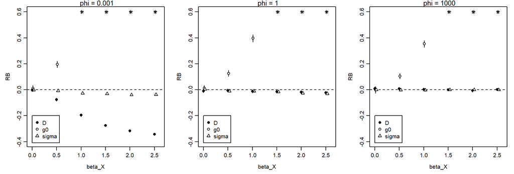

```r
plotone <- function (estD,estL,estS, phi) {
    plot(0,0, type = 'n', xlim=c(0,2.6), xlab = 'beta_X', ylab = 'RB', ylim=c(-0.4,0.6))
    abline(h=0, lty=2)
    rows <- parm$phi == phi
    addRB(parm$betaX[rows], estL[rows,], pch=21, bg='white', star = 0.6, xoffset=0.015)
    addRB(parm$betaX[rows], estS[rows,], pch=24, bg='white', star = 0.6, xoffset=0.03)
    addRB(parm$betaX[rows], estD[rows,], pch=16)
    mtext(side=3, paste0(' phi = ', phi), cex=0.8)
    legend(0, -0.2, legend=leg, pch=c(16,21,24))
}
estD <- estimateSummary(MOQsims)
estL <- estimateSummary(MOQsims, 'g0')
estS <- estimateSummary(MOQsims, 'sigma')
leg <- c('D', 'g0','sigma')
par(mfrow=c(1,3), mar=c(4,4,1,1), mgp=c(2.4,0.7,0), bty = 'o')
x <- seq(0.5,2.5,0.5)
plotone(estD, estL, estS, 0.001)
plotone(estD, estL, estS, 1)
plotone(estD, estL, estS, 1000)
```

We expect $\mbox{RB}(\hat D)$ to approach zero for very small $\phi$ because then distances are ‘shrunk’ and detectors are nearly the same. The reverse appears to be the case in these simulations. That can be attributed to the transformation applied to the random field values: whatever the original range, the transformed value at any detector lies between -1.96 and +1.96. The range of values is then inflated by the $\beta_X$ parameter (e.g., $\beta_X = 2$ scales the variable component of $\mbox{logit}(p_0_j)$ to lie between -3.92 and +3.92)

# Dey et al. 2023

Dey et al. (2023) extended the simulations of Moqanaki et al. (2021) and implemented a random effects model. Their simulation conditions differed from those of Moqanaki et al. in minor ways; here we merely try to reproduce some results with the SECR null model.

## Settings

Square grid of 1024 binary proximity detectors at unit spacing $c$.

The same conditions used for simulation and fitting.

| Parameter | Value(s) |
| --- | --- |
| detectfn | ‘HN’ |
| D | $0.40155 \sigma^{-2}$ |
| N | fixed |
| k | 0.634 |
| base g0 | 0.1, 0.3, 0.6 |
| sigma | $1.5c$ |
| noccasions | 1 |
| buffer | $3.3\sigma$ |
| nx | 64 |

## Simulation code

```r
grid1024 <- make.grid(32, 32, spacex = 1, detector = 'proximity')
mask1024 <- make.mask(grid1024, buffer = 5)
poparg <- list(Ndist = 'fixed')
detarg <- expand.arg(phi = c(1,0.05), betaX = 1, cov.structure = "exponential")
fitarg <- list(details = list(distribution = 'binomial'))
scen <- make.scenarios(noccasions = 1,
                       D          = 300/maskarea(mask1024),
                       g0         = c(0.1,0.3,0.6),
                       sigma      = 1.5,
                       detectfn   = 'HN',
                       detindex   = 1:length(detarg))
scen <- scen[order(scen$g0, scen$detindex),]
scen$scenario <- 1:6
```

```r
scenarioSummary(scen, trapset = grid1024)
```

```
##   scenario trapsindex noccasions nrepeats      D  g0 sigma detectfn     En      Er      Em     En2
## 1        1          1          1        1 1784.7 0.1   1.5        0 148.62  105.84  101.46  70.561
## 2        2          1          1        1 1784.7 0.1   1.5        0 148.62  105.84  101.46  70.561
## 3        3          1          1        1 1784.7 0.3   1.5        0 211.24  524.80  500.54 176.426
## 4        4          1          1        1 1784.7 0.3   1.5        0 211.24  524.80  500.54 176.426
## 5        5          1          1        1 1784.7 0.6   1.5        0 224.15 1135.41 1070.74 205.267
## 6        6          1          1        1 1784.7 0.6   1.5        0 224.15 1135.41 1070.74 205.267
##        esa CF rotRSE rotRSEB arrayN arrayspace arrayspan saturation detperHR.median       k
## 1 0.083277  1 0.0972  0.0798   1024     0.6667    29.227    0.22513              37 0.63368
## 2 0.083277  1 0.0972  0.0798   1024     0.6667    29.227    0.22513              37 0.63368
## 3 0.118363  1 0.0688  0.0406   1024     0.6667    29.227    0.54318              34 0.63368
## 4 0.118363  1 0.0688  0.0406   1024     0.6667    29.227    0.54318              34 0.63368
## 5 0.125599  1 0.0668  0.0371   1024     0.6667    29.227    0.80562              28 0.63368
## 6 0.125599  1 0.0668  0.0371   1024     0.6667    29.227    0.80562              28 0.63368
```

Simulate some data without fitting to check Moran’s I.

```r
DEYtest <- run.scenarios(
    nrepl       = nrepl,
    scenarios   = scen,
    trapset     = grid1024,
    maskset     = mask1024,
    CH.function = "simMOQDEY.capthist",
    fit         = FALSE,
    pop.args    = poparg,
    det.args    = detarg,
    extractfn   = MoranX)
```

```r
tempMoranI <- MoranXSummary(DEYtest, 'MoranI')
cbind(scen[,c('g0', 'detindex')], round(tempMoranI,3))
```

```
##    g0 detindex  mean    se
## 1 0.1        1 0.305 0.003
## 4 0.1        2 0.861 0.005
## 2 0.3        1 0.300 0.003
## 5 0.3        2 0.856 0.005
## 3 0.6        1 0.302 0.003
## 6 0.6        2 0.851 0.006
```

```r
tempdnpa <- MoranXSummary(DEYtest, 'dnpa')
temprpsv <- MoranXSummary(DEYtest, 'rpsv')
```

```r
parm <- attr(detarg, 'comb')[,1,drop=F]
```

```r
DEYsims <- run.scenarios(
    nrepl       = nrepl,
    scenarios   = scen,
    trapset     = grid1024,
    maskset     = list(mask1024),
    CH.function = "simMOQDEY.capthist",
    fit         = TRUE,
    pop.args    = poparg,
    det.args    = detarg,
    fit.args    = fitarg)
saveRDS(DEYsims, file = 'DEYsims.RDS')
```

DEYsims completed with 100 replicates in 805.8 minutes.

```r
cbind(g0 = scen$g0, phi = c(1,0.05)[scen$detindex], round(estimateSummary(DEYsims),4))
```

```
##    g0  phi scenario true.D nvalid    EST   seEST      RB   seRB    RSE    RMSE  rRMSE  COV
## 1 0.1 1.00        1 1784.7    100 1703.9  9.7396 -0.0452 0.0055 0.0569 126.132 0.0707 0.85
## 2 0.1 0.05        2 1784.7    100 1561.0 17.0845 -0.1253 0.0096 0.0747 280.957 0.1574 0.42
## 3 0.3 1.00        3 1784.7    100 1779.4  6.7361 -0.0029 0.0038 0.0364  67.228 0.0377 0.95
## 4 0.3 0.05        4 1784.7    100 1703.7 10.7448 -0.0454 0.0060 0.0399 134.093 0.0751 0.74
## 5 0.6 1.00        5 1784.7    100 1782.8  5.3708 -0.0010 0.0030 0.0317  53.470 0.0300 0.99
## 6 0.6 0.05        6 1784.7    100 1761.4  6.9699 -0.0130 0.0039 0.0324  73.146 0.0410 0.90
```

Broadly match Dey et al. [Table S1](https://ars.els-cdn.com/content/image/1-s2.0-S0304380023000522-mmc1.zip), but some signs of systematic difference in simulations.

## Additional DEY simulations: varying $\phi$

```r
grid1024 <- make.grid(32, 32, spacex = 1, detector = 'proximity')
mask1024 <- make.mask(grid1024, buffer = 5)
poparg <- list(Ndist = 'fixed')
detarg <- expand.arg(phi = 10^seq(-3,1,0.5), betaX = 1, cov.structure = "exponential")
fitarg <- list(details = list(distribution = 'binomial'))
scen <- make.scenarios(noccasions = 1,
                       D          = 300/maskarea(mask1024),
                       g0         = 0.1,
                       sigma      = 1.5,
                       detectfn   = 'HN',
                       detindex   = 1:length(detarg))
```

Simulate some data without fitting

```r
DEYtest2 <- run.scenarios(
    nrepl       = nrepl,
    scenarios   = scen,
    trapset     = grid1024,
    maskset     = mask1024,
    CH.function = "simMOQDEY.capthist",
    fit         = FALSE,
    pop.args    = poparg,
    det.args    = detarg,
    extractfn   = MoranX,
    varname     = 'p0')
```

```r
temp <- MoranXSummary(DEYtest2, 'MoranI')
parm <- attr(detarg, 'comb')
cbind(parm, round(temp,3))
```

```
##          phi betaX cov.structure  mean    se
## 1  0.0010000     1   exponential 0.888 0.005
## 2  0.0031623     1   exponential 0.884 0.005
## 3  0.0100000     1   exponential 0.870 0.005
## 4  0.0316228     1   exponential 0.853 0.005
## 5  0.1000000     1   exponential 0.797 0.006
## 6  0.3162278     1   exponential 0.617 0.006
## 7  1.0000000     1   exponential 0.264 0.003
## 8  3.1622777     1   exponential 0.024 0.002
## 9 10.0000000     1   exponential 0.000 0.002
```

```r
DEYsims2 <- run.scenarios(
    nrepl       = nrepl,
    scenarios   = scen,
    trapset     = grid1024,
    maskset     = list(mask1024),
    CH.function = "simMOQDEY.capthist",
    fit         = TRUE,
    pop.args    = poparg,
    det.args    = detarg,
    fit.args    = fitarg)
saveRDS(DEYsims2, file = 'DEYsims2.RDS')
```

DEYsims2 completed with 100 replicates in 846.3 minutes.

```r
estD <- estimateSummary(DEYsims2, 'D')
estL <- estimateSummary(DEYsims2, 'g0')
estS <- estimateSummary(DEYsims2, 'sigma')
cbind(g0 = scen$g0, phi = 10^seq(-3,1,0.5), round(estD,4))
```

```
##    g0        phi scenario true.D nvalid      EST      seEST       RB     seRB    RSE       RMSE
## 1 0.1  0.0010000        1 1784.7    100   1745.9 2.2795e+01  -0.0217   0.0128 0.0994 2.3008e+02
## 2 0.1  0.0031623        2 1784.7     99   1804.2 4.9966e+01   0.0110   0.0280 0.1239 4.9502e+02
## 3 0.1  0.0100000        3 1784.7    100 211497.5 2.0974e+05 117.5091 117.5245 0.1209 2.0974e+06
## 4 0.1  0.0316228        4 1784.7    100   1635.2 2.7163e+01  -0.0838   0.0152 0.0909 3.0886e+02
## 5 0.1  0.1000000        5 1784.7    100   1530.8 1.2673e+01  -0.1423   0.0071 0.0638 2.8347e+02
## 6 0.1  0.3162278        6 1784.7    100   1570.1 1.1167e+01  -0.1202   0.0063 0.0584 2.4162e+02
## 7 0.1  1.0000000        7 1784.7    100   1717.0 9.8347e+00  -0.0379   0.0055 0.0574 1.1893e+02
## 8 0.1  3.1622777        8 1784.7    100   1773.5 1.0796e+01  -0.0062   0.0060 0.0585 1.0799e+02
## 9 0.1 10.0000000        9 1784.7    100   1777.5 9.2500e+00  -0.0040   0.0052 0.0578 9.2311e+01
##       rRMSE    COV
## 1    0.1289 0.9200
## 2    0.2774 0.9495
## 3 1175.2432 0.9100
## 4    0.1731 0.7000
## 5    0.1588 0.3600
## 6    0.1354 0.3800
## 7    0.0666 0.8800
## 8    0.0605 0.9400
## 9    0.0517 0.9800
```

```r
getcounts(DEYsims2)
```

```
##        n      r   nmov    dpa      rse   rpsv
## 1 149.73 221.94 221.94 2.1876 0.125540 1.4687
## 2 146.35 218.90 218.90 2.1699      Inf    NaN
## 3 141.46 194.77 194.77 2.0670      Inf    NaN
## 4 146.73 198.37 198.37 2.1653 0.116654 1.4668
## 5 150.38 199.84 199.84 2.2431 0.090212 1.4334
## 6 155.79 182.07 182.07 2.1573 0.082175 1.4125
## 7 167.31 177.54 177.54 2.0598 0.078206 1.4425
## 8 169.93 169.96 169.96 1.9999 0.078422 1.4605
## 9 171.22 174.30 174.30 2.0177 0.077562 1.4679
```

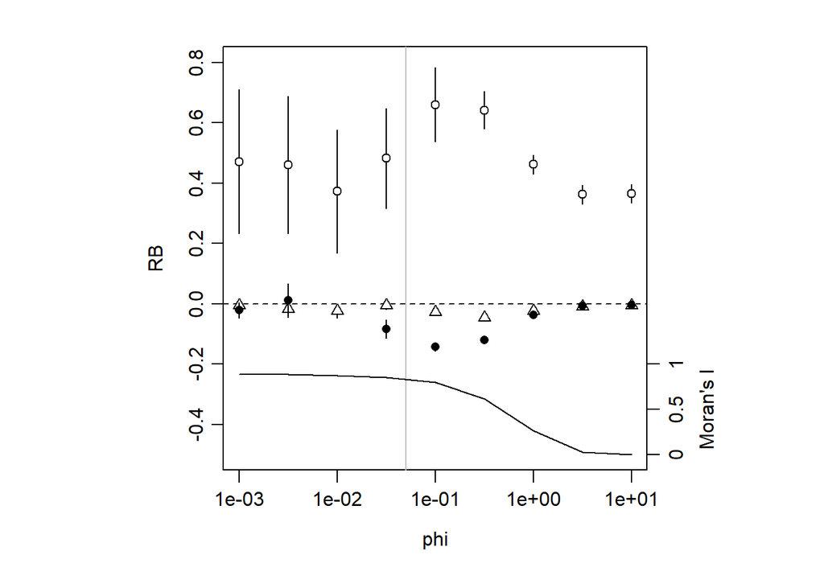

```r
leg <- c('D', 'g0','sigma')
phi <- 10^seq(-3,1,0.5)
par(mfrow = c(1,1), mar = c(5,4,2,2), mgp = c(2.4,0.7,0), pty = 's', bty = 'o')
plot(1,1, type = 'n', xlim = c(0.001,10), xlab = 'phi', ylab = 'RB', log = 'x', ylim = c(-0.5,0.8))
abline(h = 0, lty = 2)
addRB(phi, estL, pch = 21, bg = 'white', star = 0.8)
addRB(phi, estS, pch = 24, bg = 'white', star = 0.8)
addRB(phi, estD, pch = 16)
legend(0, -0.2, legend = leg, pch = c(16,21,24))
abline (v = 0.05, col = 'grey')
lines(phi, temp[,'mean']*0.3 - 0.5)  # MoranI
axis(4, at = seq(-0.5,-0.2, 0.15), c(0,0.5,1))
mtext(side = 4, line = 2, at = -0.35, "Moran's I")
```

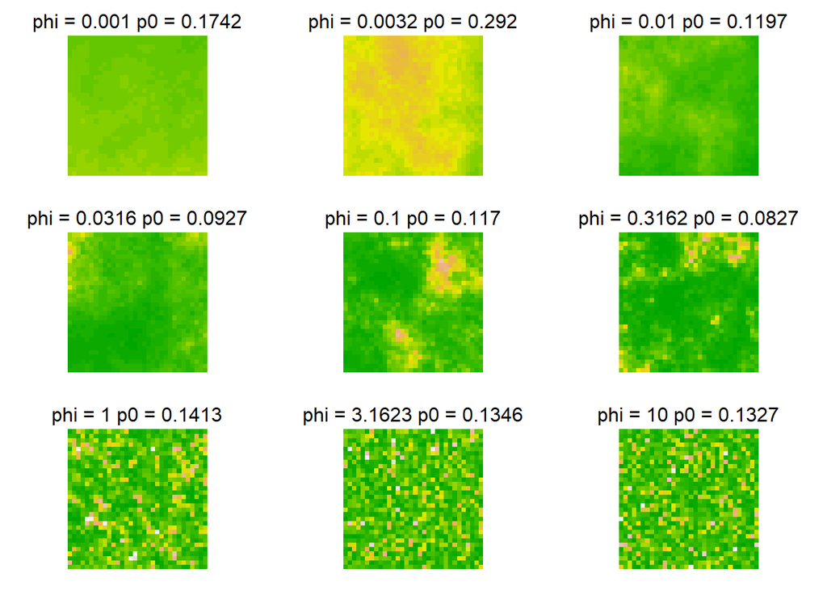

```r
pop <- sim.popn(D = 300/maskarea(mask1024), core = grid1024, buffer = 5, Ndist = 'fixed')
par(mfrow = c(3,3), mar = c(1,1,2,1))
for (phi in 10^seq(-3,1,0.5)) {
    ch <- simMOQDEY.capthist(grid1024, popn = pop, detectfn = 'HN',
                           detectpar = list(g0 = 0.1, sigma = 1.5),
                           phi = phi, betaX = 1, cov.structure = "exponential")
    covariates(grid1024)$p0 <- attr(ch, 'p0')
    plot(as.mask(grid1024), cov = 'p0', dots = FALSE, legend = FALSE, border = 1,
         breaks = c(seq(0,0.6,0.02),1))
    mtext(side = 3, paste0('phi = ', round(phi,4), ' p0 = ', round(mean(attr(ch, 'p0')),4)))
}
```

# Relationship between SARE and individual heterogeneity

It has long been recognised that variation among detectors (SARE) causes heterogeneity of detection among individuals that leads to bias in $\hat D$ (Royle et al. (2013), Efford (2014)). Whether induced individual heterogeneity is a sufficient explanation for the observed $\mbox{RB}(\hat D)$ is an open question. The hypothesis implies that $\mbox{RB}(\hat D)$ is tightly correlated with a measure of heterogeneity over a variety of SARE scenarios that yield similar precision.

Heterogeneity in non-spatial capture-recapture is measured by the coefficient of variation of detection probability $\mbox{CV}(p_i)$ (Carothers 1979, Seber 1982:, Pledger and Efford 1998). The issue is more subtle in SECR because of the interaction between detection parameters (e.g., $\lambda_0, \sigma$). Efford and Mowat (2014) proposed $\mbox{CV}(a_i)$ as a suitable measure, where $a_i = \int p_\cdot(\vec x) \, d\vec x$ and $p_\cdot(\vec x) = 1 - \exp(-\sum_s\sum_k h_{sk}(\vec x))$ where $h_{sk}(\vec x)$ is the hazard of detection at detector $k$ on occasion $s$ for an animal at $\vec x$. Under the hazard halfnormal detection model $h_{sk}(\vec x) = \lambda_0 \exp\left(\frac{-|\vec x - \vec x_k|^2}{2\sigma^2}\right)$

SARE scenarios have been limited to variation in $\lambda_0$, with $\sigma$ constant, and for these it is sufficient to consider $\mbox{CV}(\lambda_0)$.